# Using phylogenetic trees in R

## ggtree layouts

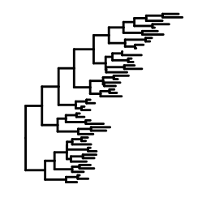

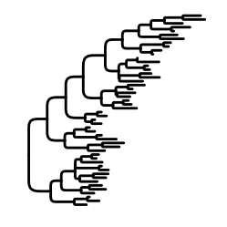

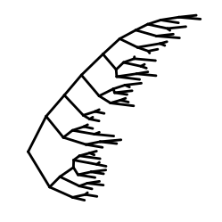

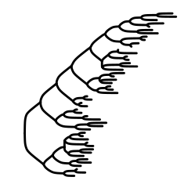

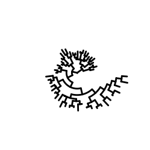

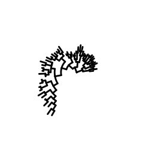

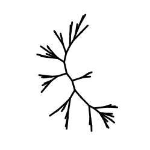

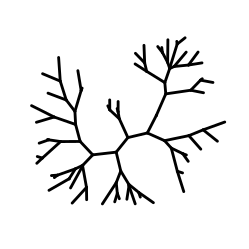

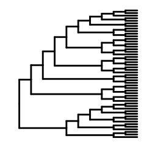

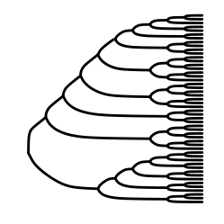

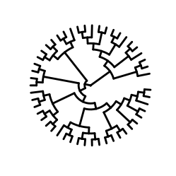

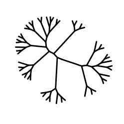

## Phylogenetic Tree Annotation

- `geom_tiplab()` — tip labels
- `geom_nodelab()` — internal node labels
- `geom_treescale()` — scale bar

```r
ggtree(tree) +
  geom_tiplab(size = 3, color = "blue") +
  geom_treescale(x = 0.5, y = 0.5, width = 0.1)
```

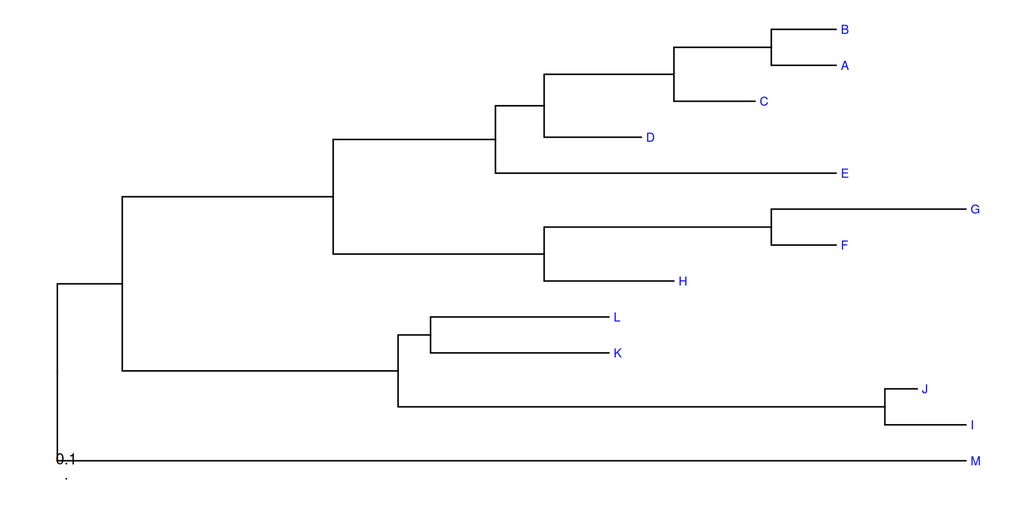

## Customizing tree appearance

Since `ggtree` is ggplot2-based:

- `theme_tree()` — minimal tree theme
- `xlim()` / `ylim()` — adjust space around the tree
- `geom_nodepoint()` / `geom_tippoint()` — symbols at nodes/tips
- `geom_text2()` — text at nodes

## Highlighting or annotating clades

- `geom_hilight(node, fill)` — shaded rectangle under a clade
- `geom_cladelabel(node, label)` — text label on a clade

```r
ggtree(bird.orders) +
  geom_tiplab() +
  geom_treescale() +
  geom_hilight(node = 30, fill = "goldenrod", alpha = 0.3) +
  ggplot2::xlim(0, 50)
```

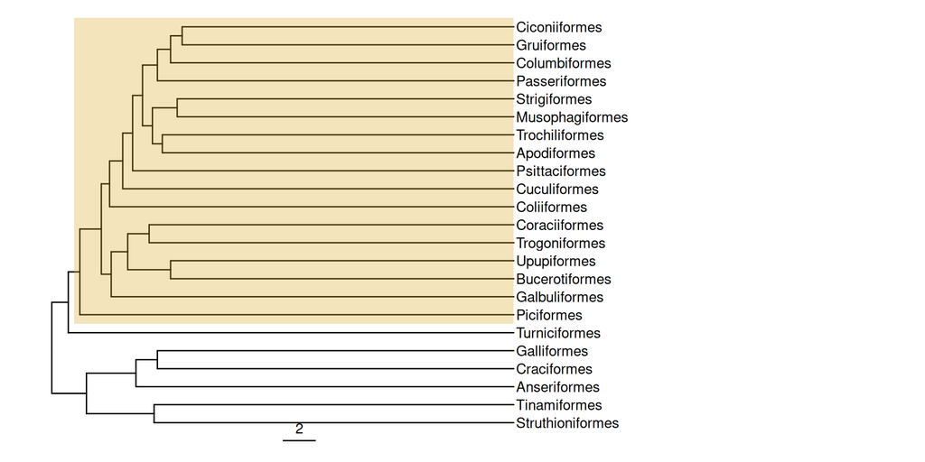

# Section 6: Annotating trees with metadata

## Annotation tree with metadata

Common metadata types:

- **Traits** (body size, habitat)
- **Taxonomic info** (family, order)
- **Geography or host** (pathogen phylogenies)
- **Temporal data** (sample collection year)
- **Statistical results** (dN/dS ratios on branches)

## Combining tree with tip data

```r
tree_example <- rtree(5, tip.label = LETTERS[1:5])
trait_data <- data.frame(
  label  = LETTERS[1:5],
  Status = c("Endangered", "Not Endangered", "Not Endangered",
             "Endangered", "Endangered")
)
trait_data
```

```
  label         Status
1     A     Endangered
2     B Not Endangered
3     C Not Endangered
4     D     Endangered
5     E     Endangered
```

## Attaching data to the tree

`%<+%` attaches a data frame by matching the `label` column:

```r
p <- ggtree(tree_example) %<+% trait_data +
  geom_tiplab(aes(color = Status), size = 4) +
  theme_tree() +
  scale_color_manual(values = c("red", "green"))
p
```

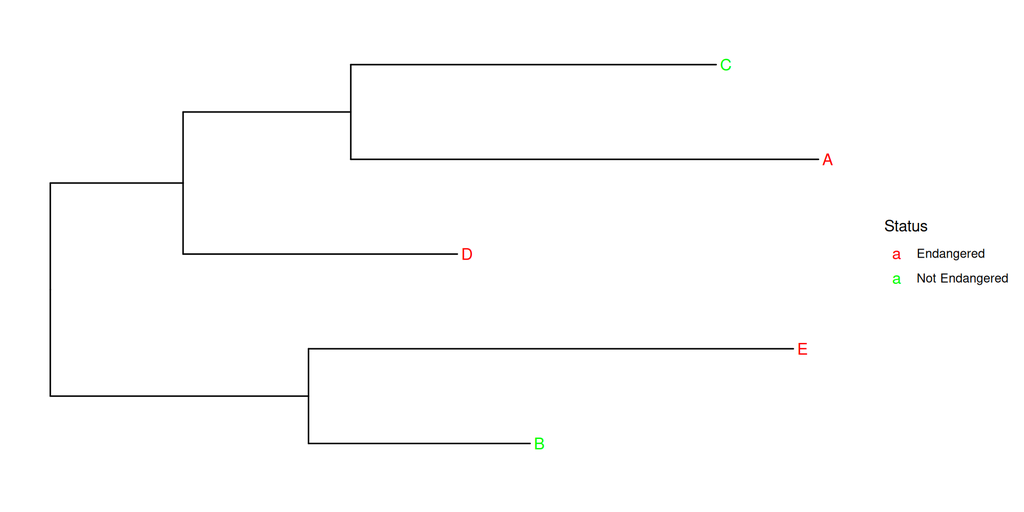

## Attaching data to the tree

```r
p + geom_tippoint(aes(color = Status), size = 3)
```

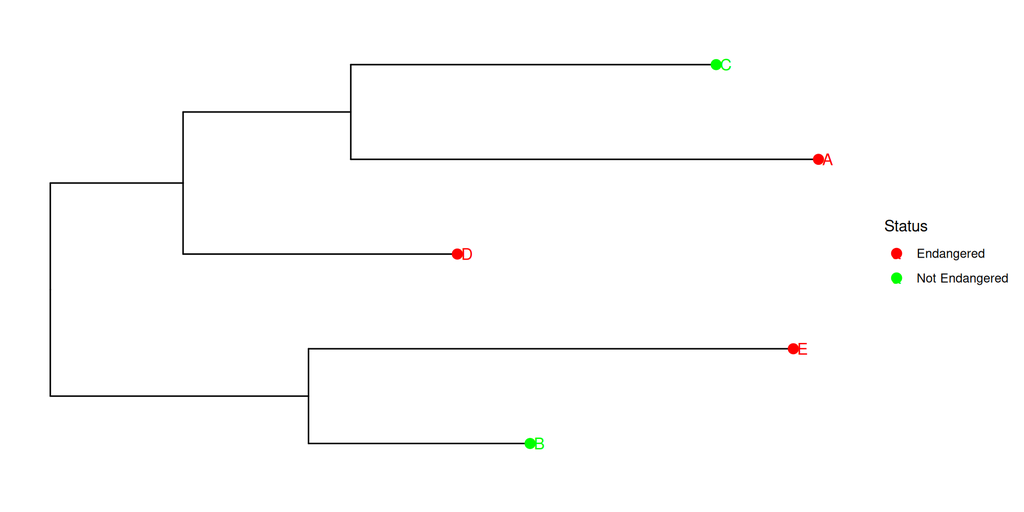

> 📝 **Task 2** — Assign bird.orders tips to “Waterbirds” (Anseriformes, Gaviiformes, Podicipediformes, Pelecaniformes, Ciconiiformes, Sphenisciformes, Procellariiformes) and “Other”. Plot with `ggtree` + `%<+%`, coloring tip points by group.

## Attaching data to the tree — continuous trait

```r
tree_example2 <- rtree(20, tip.label = LETTERS[1:20])
trait_data2 <- data.frame(
  label      = LETTERS[1:20],
  TraitValue = rnorm(20, mean = 5, sd = 2)
)
p2 <- ggtree(tree_example2) %<+% trait_data2 +
  geom_tippoint(aes(color = TraitValue), size = 6)
p2
```

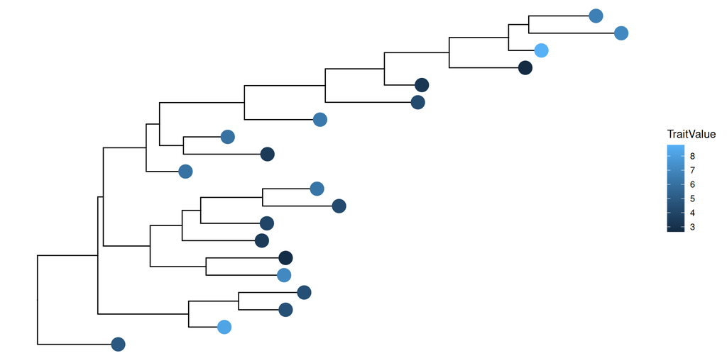

# Section 7: Time-calibrated trees

## Joining tree with metadata using `as.treedata`

When metadata has many columns, use `full_join()` + `as.treedata()`:

```r
meta <- read_tsv("data/ncov_metadata.tsv")

td <- full_join(as_tibble(tree), meta, by = c("label" = "strain")) |>
        as.treedata()

ggtree(td, mrsd = max(meta$decimal_date), as.Date = TRUE) +
  geom_tippoint(aes(color = Nextstrain_clade))
```

- `as_tibble(tree)` converts the `phylo` object to a tibble with a `label` column
- `full_join()` attaches all metadata columns by tip name
- `as.treedata()` converts back so `ggtree` can access those columns in `aes()`

## Time-calibrated trees with `mrsd`

- `mrsd` = most-recent sampling date (character `"YYYY-MM-DD"` or numeric)
- `as.Date = TRUE` — display x-axis as calendar dates
- `theme_tree2()` — shows the x-axis (time axis)

```r
beast_file <- system.file("examples/MCC_FluA_H3.tree", package = "ggtree")
beast_tree <- read.beast(beast_file)

ggtree(beast_tree, mrsd = "2013-01-01") +
  geom_tiplab(size = 2, align = TRUE, linesize = 0.5) +
  theme_tree2()
```

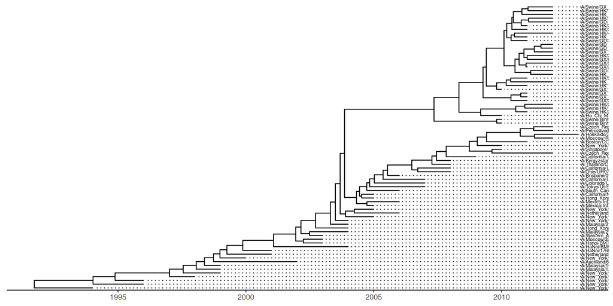

## Checking branch-length units

`mrsd` only works when branches are in **years** (time-calibrated tree).

```r
# For a SARS-CoV-2 tree spanning ~6 years this should return ~6
max(node.depth.edgelength(tree))
```

- Result ≈ 6 → branches in years, `mrsd` will work correctly
- Result ≈ 0.001 → branches in substitutions/site → need to time-calibrate first

# Section 8: Heatmaps with `gheatmap`

## Attaching heatmap to the tree

`gheatmap()` glues a **wide matrix** of data cells to the right of a tree: - Each row = one tip (aligned by **row name**, not row order) - Each column = one variable (e.g. genotype, mutation presence/absence)

```r
beast_file    <- system.file("examples/MCC_FluA_H3.tree", package = "ggtree")
beast_tree    <- read.beast(beast_file)
genotype_file <- system.file("examples/Genotype.txt", package = "ggtree")
genotype      <- read.table(genotype_file, sep = "\t", stringsAsFactors = FALSE)

p3 <- ggtree(beast_tree, mrsd = "2013-01-01") +
  geom_tiplab(size = 2, align = TRUE, linesize = 0.5) +
  theme_tree2()
head(genotype)
```

```
                               PB2  PB1   PA     HA   NP    NA.    M   NS
A/Swine/Binh_Duong/03_10/2010 trig trig trig HuH3N2 trig HuH3N2 trig trig
A/Swine/Binh_Duong/03_08/2010 trig trig trig HuH3N2 trig HuH3N2 trig trig
A/Swine/HK/2857/2011           pdm  pdm  pdm HuH3N2 trig HuH3N2  pdm  pdm
A/Swine/HK/1071/2012           pdm  pdm  pdm HuH3N2 trig HuH3N2  pdm  pdm
A/Swine/HK/2454/2012           pdm  pdm  pdm HuH3N2 trig HuH3N2  pdm  pdm
A/Swine/GX_NS2783/2010         pdm  pdm  pdm HuH3N2  pdm HuH3N2  pdm  pdm
```

## Attaching heatmap to the tree

```r
gheatmap(p3, genotype, offset = 8, width = 0.6,
         colnames = FALSE, legend_title = "genotype") +
  scale_x_ggtree()
```

[figure not shown]

## `pivot_wider` for `gheatmap`

`gheatmap` requires **wide** format: rows = tips, columns = mutations.

Long → wide with `pivot_wider`:

```r
key_muts <- c("S:D614G", "S:N501Y", "S:E484K", "S:L452R", "S:P681H")

mut_wide <- spike_long |>
  filter(mutation %in% key_muts) |>
  mutate(present = "present") |>
  pivot_wider(names_from  = mutation,
              values_from = present,
              values_fill = "absent") |>
  column_to_rownames("strain")
```

## `gheatmap` — alignment pitfalls

**Critical:** `gheatmap` aligns by **row name**, not row order.

Two preparations are always needed:

**1. Force every expected column to exist**

```r
# pivot_wider silently drops columns absent from all tips
for (m in setdiff(key_muts, colnames(mut_wide))) mut_wide[[m]] <- "absent"
mut_wide <- mut_wide[, key_muts]   # enforce column order
```

**2. Force every tree tip to be a row**

```r
# tips with no key mutations are missing from the pivoted matrix
missing_tips <- setdiff(tree$tip.label, rownames(mut_wide))
if (length(missing_tips) > 0) {
  pad <- as.data.frame(
    matrix("absent", nrow = length(missing_tips), ncol = ncol(mut_wide),
           dimnames = list(missing_tips, colnames(mut_wide)))
  )
  mut_wide <- rbind(mut_wide, pad)
}
```

> 📝 **Task 3** — Inspect `genotype` (loaded above) with `head()` and `class()`. Call `gheatmap()` with `offset = 5`, `width = 0.4`, `colnames = TRUE`. Customize fill colors with `scale_fill_manual()`.